# ChIP_Seq_Analysis

Maximilian Greil

21 4 2021

## 0) Load data

In this ChIP-Seq analysis the goal was analyze two ChIP-Seq data sets and compare the results.

The two data sets chosen for this ChIP-Seq analysis consist of `PRDM1` and and `ZNF414`.

Gene `PRDM1` encodes protein `PR domain zinc finger protein 1`/`B lymphocyte-induced maturation protein-1 (BLIMP-1)`. This protein is expressed in both B and T cells and plays a significant role in B cell development and antibody production.

Gene `ZNF414` encodes protein `Zinc Finger Protein 414`. Its function is not clear but it may be involved in transcriptional regulation.

These two data sets were chosen because an analysis of significant overlaps could enable more inside on how these two proteins may form a complex or have interaction in regulation chromosome remodelling or gene expression.

The two data sets analyzed were downloaded from [ENCODE](https://www.encodeproject.org/):`PRDM1` ([data set](https://www.encodeproject.org/experiments/ENCSR977FEF/) – [peaks](https://www.encodeproject.org/files/ENCFF719BHI/)), `ZNF414` ([data set](https://www.encodeproject.org/experiments/ENCSR224NQI/) – [peaks](https://www.encodeproject.org/files/ENCFF409BJK/)).

Both peaks for `PRDM1` and `ZNF414` were downloaded in `bed narrowPeak` format and read-in using R package `ChIPseeker` function `readPeakFile` for further analysis.

Both peak files contained `IDR thresholded peaks` and used genome assembly `GRCh38`.

## 1) Venn diagram comparing the overlap of binding sites between PRDM1 and ZNF414

Both `PRDM1` and `ZNF414` showed a large number of peaks. The overlap between the two showed 2106 peaks.

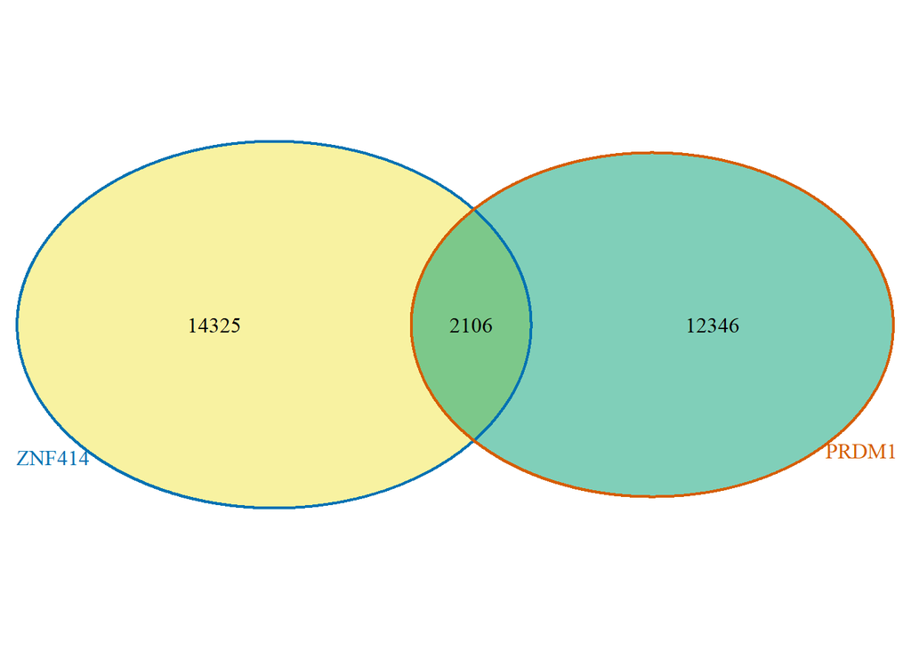

## 2) Metaplot of PRDM1 and ZNF414 around the transcription start sites (TSS)

### 2.1) Heatmap of ChIP binding to TSS regions

First, for calculating the profile of ChIP peaks binding to TSS regions, we prepared the TSS regions, which are defined as the flanking sequence of the TSS sites. Therefore, we aligned the peaks that mapped to these regions.

`PRDM1///ZNF414` stands for the overlaps between `PRDM1` and `ZNF414`.

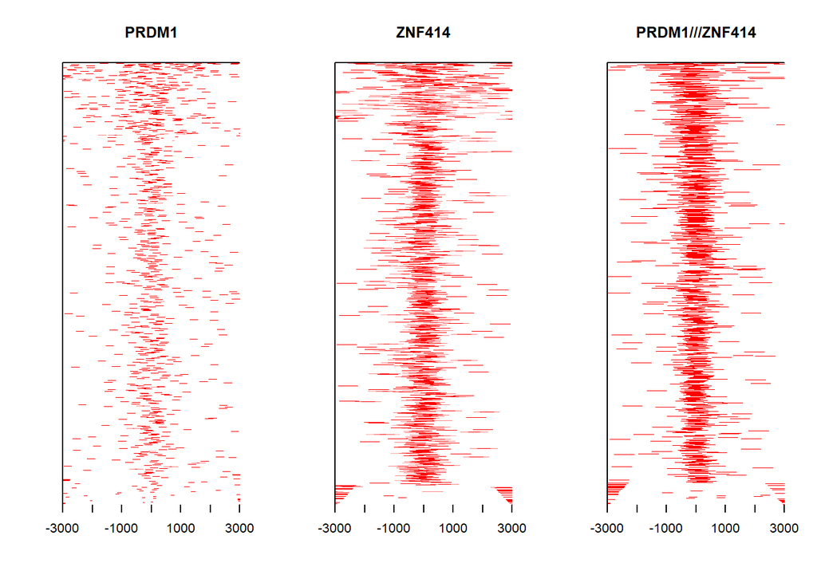

### 2.2) Average Profile of ChIP peaks binding to TSS region

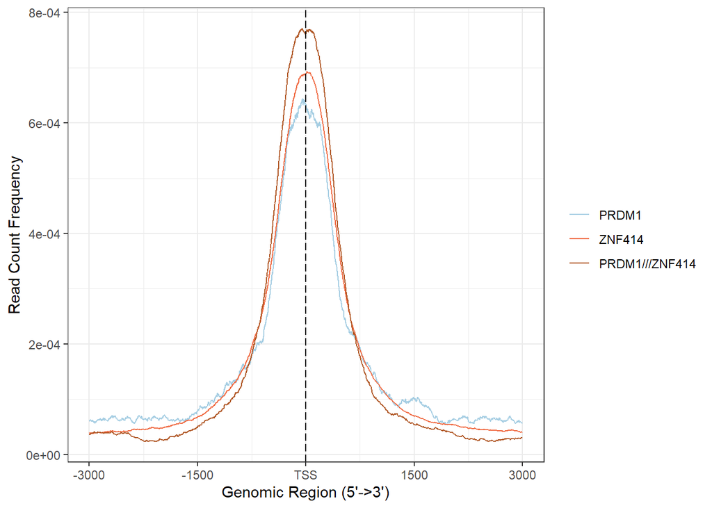

## 3) Annotate the peaks for genomic features such as intron, exon, 3’UTR, etc and compare the annotations between between PRDM1 and ZNF414

First, we summarized the distribution of peaks `PRMD1` and `ZNF414` over different type of features such as exon, intron, enhancer, proximal promoter, 5’ UTR and 3’ UTR.

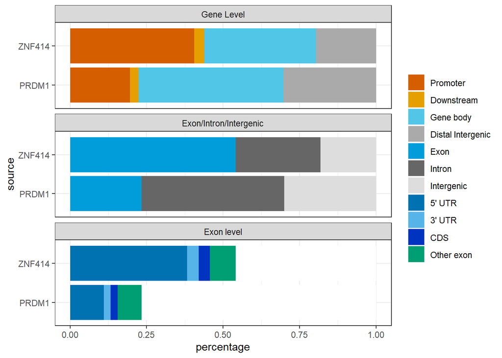

We also checked the genomic element distribution for the overlaps.

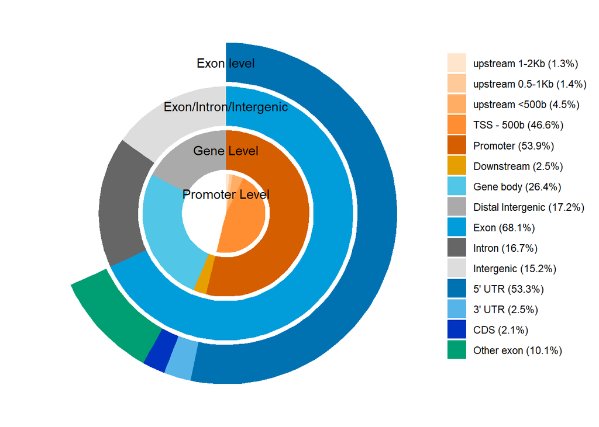

We created upsetplots for `PRMD1`, `ZNF414` and the overlaps.

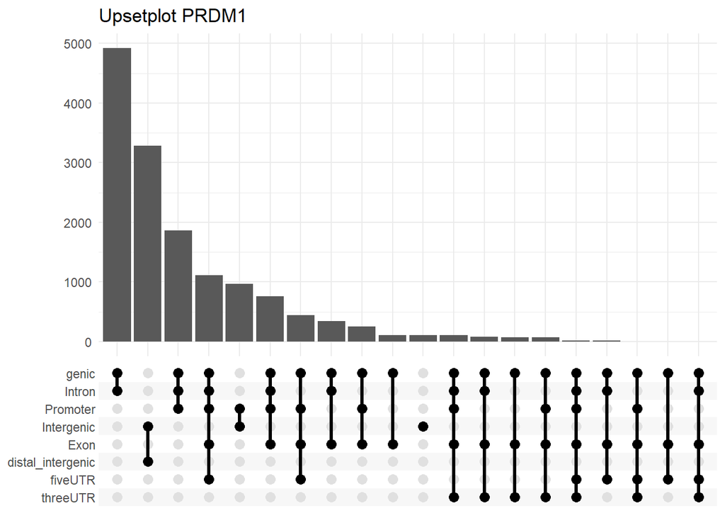

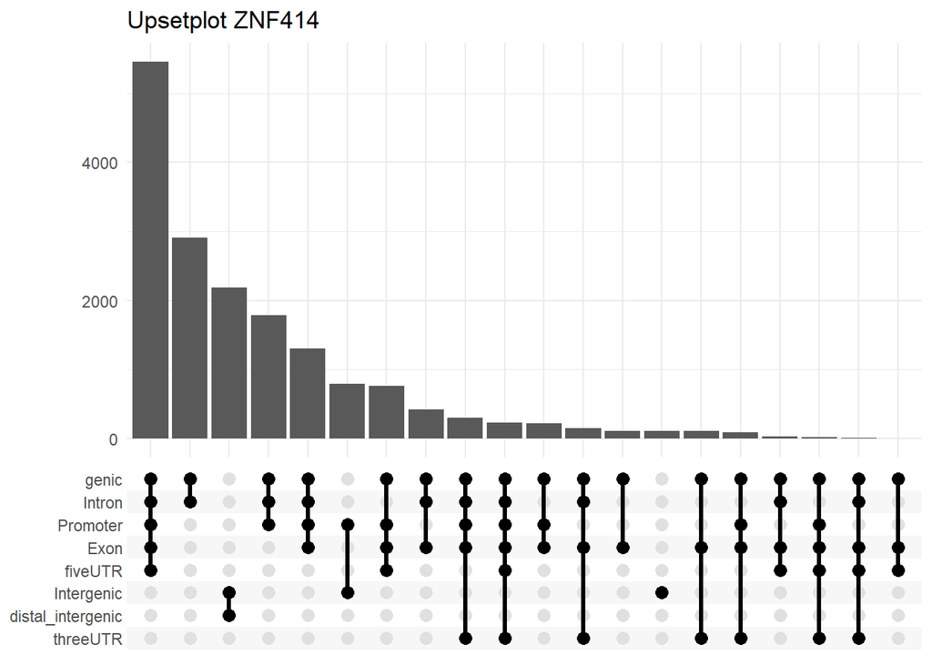

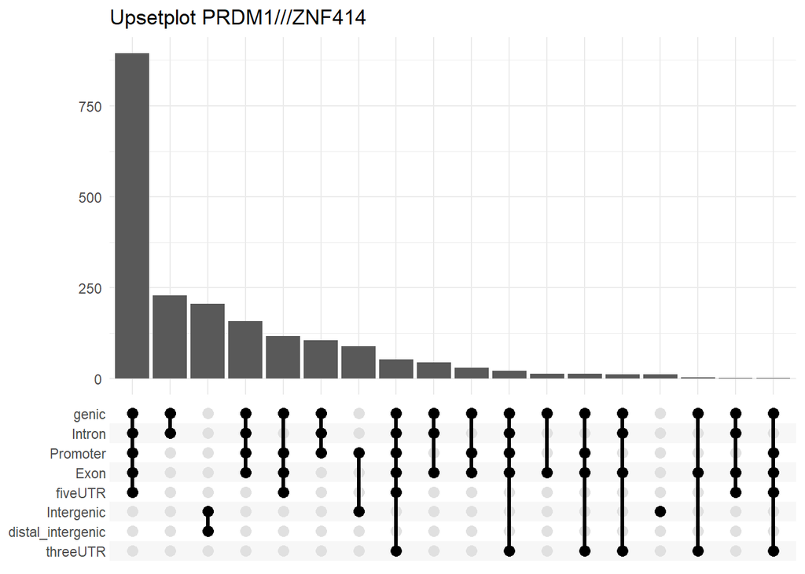

We calculated the percentage of binding sites upstream and downstream from the TSS of the nearest genes and visualized the distribution.

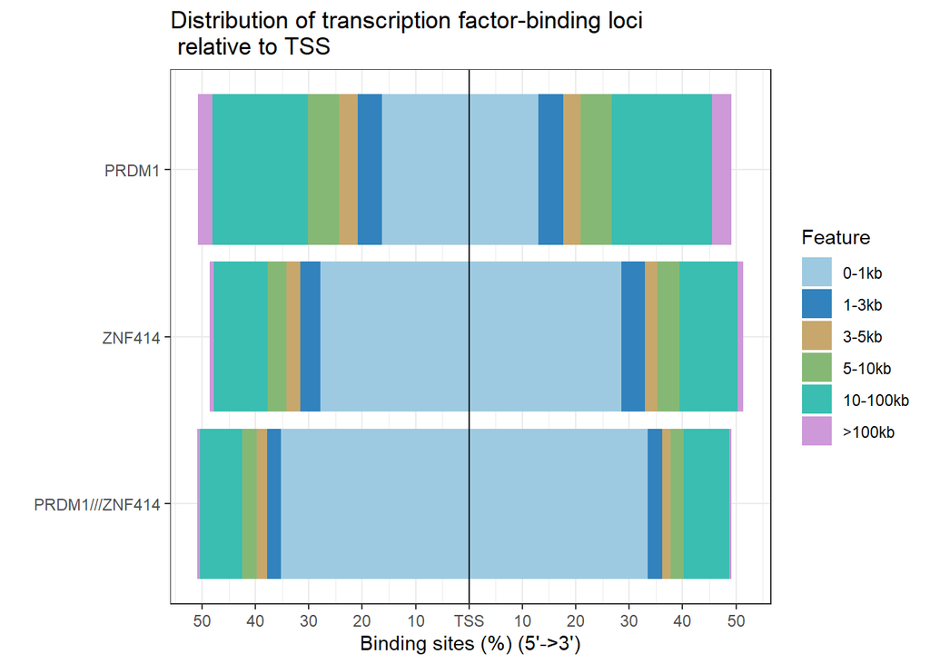

## 4) Assign peaks to genes – then perform pathway enrichment.

For enrichment of the annotated peaks R package `clusterProfiler` function `enricher` was used. For the enrichment we used ontology gene sets of species Homo sapiens from R package `msigdbr`. Finally, the found pathways were filtered to contain only terms with an adjusted p-value smaller than or equal 0.05.

Additionally to the ontology gene sets from R package `msigdbr`, we performed another gene enrichment analysis. Gene ontology is a very limited pathway annotation that is hard to interpret for many applications. Therefore, we also performed a broad-spectrum [enrichr](https://maayanlab.cloud/Enrichr/) analysis using R package `enrichR`.

In our enrichr analysis we performed pathway enrichment analysis for all available 172 `enrichR` databases. Finally, the found pathways were filtered to contain only terms with an adjusted p-value smaller than or equal 0.05 and a combined score greater 100.

The formula for the combined score (c) is `ln(p) * z`. Variable `p` is the p-value computed using Fisher’s exact test and variable `z` is the z-score computed to assess the deviation from the expected rank.

### 4.1) What are genes shared in the overlap between PRDM1 and ZNF414?

**Table 1** shows the identified 1853 genes shared in the overlap between PRDM1 and ZNF414.

|  | ensgene | entrez | symbol | start | end | description |
| --- | --- | --- | --- | --- | --- | --- |
| 1 | ENSG00000001167 | 4800 | NFYA | 41072945 | 41099976 | nuclear transcription factor Y subunit alpha [Source:HGNC Symbol;Acc:HGNC:7804] |
| 2 | ENSG00000002834 | 3927 | LASP1 | 38869859 | 38921770 | LIM and SH3 protein 1 [Source:HGNC Symbol;Acc:HGNC:6513] |
| 3 | ENSG00000003137 | 56603 | CYP26B1 | 72129238 | 72148038 | cytochrome P450 family 26 subfamily B member 1 [Source:HGNC Symbol;Acc:HGNC:20581] |
| 4 | ENSG00000003393 | 57679 | ALS2 | 201700554 | 201781189 | ALS2, alsin Rho guanine nucleotide exchange factor [Source:HGNC Symbol;Acc:HGNC:443] |
| 5 | ENSG00000003402 | 8837 | CFLAR | 201116104 | 201176687 | CASP8 and FADD like apoptosis regulator [Source:HGNC Symbol;Acc:HGNC:1876] |
| 6 | ENSG00000003436 | 7035 | TFPI | 187464230 | 187565760 | tissue factor pathway inhibitor [Source:HGNC Symbol;Acc:HGNC:11760] |
| 7 | ENSG00000004864 | 10165 | SLC25A13 | 96120220 | 96322147 | solute carrier family 25 member 13 [Source:HGNC Symbol;Acc:HGNC:10983] |
| 8 | ENSG00000005001 | 64063 | PRSS22 | 2852727 | 2858170 | protease, serine 22 [Source:HGNC Symbol;Acc:HGNC:14368] |
| 9 | ENSG00000005175 | 79657 | RPAP3 | 47661249 | 47706061 | RNA polymerase II associated protein 3 [Source:HGNC Symbol;Acc:HGNC:26151] |
| 10 | ENSG00000005436 | 6936 | GCFC2 | 75652000 | 75710989 | GC-rich sequence DNA-binding factor 2 [Source:HGNC Symbol;Acc:HGNC:1317] |

[output cut: 1843 more lines]

### 4.2) What are pathways/genesets shared in the overlap between PRDM1 and ZNF414 for ontology gene sets from R package `msigdbr`?

**Table 2** shows the 155 pathways/genesets shared in the overlap between PRDM1 and ZNF414.

|  | Description | p.adjust | geneID | Count |
| --- | --- | --- | --- | --- |
| GO:0034660 | GO_NCRNA_METABOLIC_PROCESS | 5.80485710802719e-07 | 10412/55781/134430/153443/51520/6208/79727/339487/192669/801…… | 80 |
| GO:0022613 | GO_RIBONUCLEOPROTEIN_COMPLEX_BIOGENESIS | 3.34028477767655e-06 | 56853/10412/55781/134430/153443/6208/192669/51118/26828/3873…… | 75 |
| GO:0006401 | GO_RNA_CATABOLIC_PROCESS | 1.39472854856852e-06 | 5693/23034/677/55051/3842/10949/6208/23367/79727/51441/19266…… | 69 |
| GO:0034470 | GO_NCRNA_PROCESSING | 1.0517912524883e-06 | 10412/55781/134430/153443/6208/79727/339487/192669/51118/387…… | 68 |
| GO:0005635 | GO_NUCLEAR_ENVELOPE | 0.000151041370659794 | 81929/26049/662/199953/148327/10456/4000/54498/5621/29107/66…… | 68 |
| GO:0008380 | GO_RNA_SPLICING | 0.00031237610498316 | 8106/10914/56853/10949/3187/339487/10465/26828/58155/1019542…… | 68 |
| GO:0030055 | GO_CELL_SUBSTRATE_JUNCTION | 0.000126864503643072 | 3313/23092/6208/10487/3716/22823/1266/6714/8496/8994/2317/21…… | 63 |
| HP:0000534 | HP_ABNORMAL_EYEBROW_MORPHOLOGY | 0.00629424029973103 | 26277/55012/27125/3313/11285/473/8289/4000/6635/1457/8195/54…… | 61 |
| GO:0006979 | GO_RESPONSE_TO_OXIDATIVE_STRESS | 0.00585582391947642 | 5693/2353/1843/8614/80149/5052/2730/10628/4548/140809/5621/5…… | 60 |
| HP:0001260 | HP_DYSARTHRIA | 0.0109948997076599 | 8106/440193/23600/3295/8878/473/55187/3208/65260/25782/80025…… | 60 |

[output cut: 145 more lines]

### 4.3) What pathways differ for ontology gene sets from R package `msigdbr`?

**Table 3** shows the 37 pathways that differ between the overlap and PRDM1, i.e. pathways that are in the overlap but not in PRDM1.

|  | Description | geneID |
| --- | --- | --- |
| GO:0016569 | GO_COVALENT_CHROMATIN_MODIFICATION | 51562/5926/91748/55100/891/9682/55929/22823/9869/26097/51043…… |
| GO:0033044 | GO_REGULATION_OF_CHROMOSOME_ORGANIZATION | 26277/55100/26272/891/55781/324/10111/1843/22823/9869/26097/…… |
| GO:0090305 | GO_NUCLEIC_ACID_PHOSPHODIESTER_BOND_HYDROLYSIS | 10111/192669/80149/5111/144715/51367/7316/55802/55720/201164…… |
| GO:0015931 | GO_NUCLEOBASE_CONTAINING_COMPOUND_TRANSPORT | 8106/677/55051/81929/55781/23443/26097/23381/9804/29107/5100…… |
| GO:1901293 | GO_NUCLEOSIDE_PHOSPHATE_BIOSYNTHETIC_PROCESS | 133686/102157402/10111/3208/5538/25874/80025/5740/514/517/10…… |
| GO:0006403 | GO_RNA_LOCALIZATION | 8106/677/55051/81929/55781/26097/23381/9804/29107/55110/8086/6396/7048/55164/22794/10642/6426/79902/6432/87178/7514/5903/55677/130132/10643/23165/55795/51010/7248/29894/6209/7538/11338/5073/23049 |
| GO:0005840 | GO_RIBOSOME | 92259/23107/6208/23367/9636/64960/387338/6232/1939/6238/10985/6165/6147/6143/6155/51649/3396/64978/6201/87178/51263/6160/65080/130916/219927/64976/6122/6209/84769/6217/6223/6205/6189/23/5935 |
| GO:0006338 | GO_CHROMATIN_REMODELING | 57680/55320/55051/473/8289/22955/9682/55929/9869/7150/5927/23272/23135/6871/6605/6603/2186/1788/1058/23314/5757/144108/23081/401541/55636/4609/84954/3720/8366/3159/283899/10847/80152/54617 |
| GO:0051236 | GO_ESTABLISHMENT_OF_RNA_LOCALIZATION | 8106/677/55051/81929/55781/26097/23381/9804/29107/55110/8086/6396/7048/22794/10642/6426/79902/6432/87178/7514/5903/55677/130132/10643/23165/55795/7248/29894/6209/7538/11338/23049 |
| GO:0005681 | GO_SPLICEOSOMAL_COMPLEX | 3187/10465/58155/10625/6635/6628/6629/55110/6434/54883/22794/51747/6426/1655/6936/10713/220988/4691/9092/143884/3185/3190/1153/6625/11338/55692/10081/6627/5935 |

[output cut: 27 more lines]

**Table 4** shows the 22 pathways that differ between the overlap and ZNF414, i.e. pathways that are in the overlap but not in ZNF414.

|  | Description | geneID |
| --- | --- | --- |
| HP:0031105 | HP_ABNORMAL_UTERUS_MORPHOLOGY | 324/79577/6714/4665/6778/7048/6928/5889/8313/5573/4436/2956/2188/100144748/5395/2176/10395/6794/581/2072/4088 |
| GO:0060147 | GO_REGULATION_OF_POSTTRANSCRIPTIONAL_GENE_SILENCING | 81929/79727/80149/8086/6895/9612/6396/8994/5430/6774/1655/79902/23369/5903/283131/23165/6023/5605/7538/8366 |
| HP:0045075 | HP_SPARSE_EYEBROW | 55012/11285/4000/6635/54453/8085/6926/3728/84168/100151683/117581/4781/6023/3190/8216/55697/8925/25942 |
| HP:0033020 | HP_FEMALE_REPRODUCTIVE_SYSTEM_NEOPLASM | 324/79577/6714/4665/6778/8313/5573/4436/2956/100144748/5395/10395/6794/581 |
| HP:0010622 | HP_NEOPLASM_OF_THE_SKELETAL_SYSTEM | 324/8878/4000/4193/7048/8148/5573/4436/2956/5395/7248/2131/6223/22909 |
| HP:0100707 | HP_ABNORMAL_ASTROCYTE_MORPHOLOGY | 324/8878/5621/2064/2896/4137/4436/2956/5395/7248 |
| GO:1901976 | GO_REGULATION_OF_CELL_CYCLE_CHECKPOINT | 26272/891/1843/406991/348654/55795/57805/5514/10116 |
| HP:0000858 | HP_IRREGULAR_MENSTRUATION | 2353/1528/2908/4000/5573/84168/9049/64072 |
| GO:0010738 | GO_REGULATION_OF_PROTEIN_KINASE_A_SIGNALING | 8165/5573/9049/56892/4282/5141/9465/4157 |
| GO:0070920 | GO_REGULATION_OF_PRODUCTION_OF_SMALL_RNA_INVOLVED_IN_GENE_SILENCING_BY_RNA | 79727/80149/6895/9612/6774/1655/6023/5605 |

[output cut: 12 more lines]

### 4.4) What are pathways/genesets shared in the overlap between PRDM1 and ZNF414 for pathways from R package `enrichR`?

**Table 5** shows the 461 pathways/genesets shared in the overlap between PRDM1 and ZNF414.

|  | Database | Term | Overlap | P.value | Adjusted.P.value | Odds.Ratio | Combined.Score | Genes |
| --- | --- | --- | --- | --- | --- | --- | --- | --- |
| 1 | Enrichr_Submissions_TF-Gene_Coocurrence | MNT | 108/299 | 2.93588622531567e-38 | 5.05266019376827e-35 | 5.94526944531993 | 513.797463516959 | MIDN;ZMYND8;NAB2;NR3C1;ETS2;ACTG1;ZFP36;RGS2;ZMIZ1;MYC;FTH1;ZC3H12A;PIM1;JUNB;IER5;GABARAPL1;WSB1;CIRBP;NEAT1;FOXP1;DDIT4;TXNIP;ULK1;MALAT1;TRIB1;SQSTM1;PFKFB3;SRCAP;MAZ;ZBTB4;NDRG1;ZFP36L2;ZFP36L1;AB… |
| 2 | Enrichr_Submissions_TF-Gene_Coocurrence | PPP1R10 | 107/299 | 1.74085846626242e-37 | 1.49800871021881e-34 | 5.85579427083333 | 495.641864397672 | MDC1;MIDN;ZMYND8;SERPINE1;ETS2;ACTG1;MT2A;ZFP36;RGS2;MYC;CFL1;PIM1;CCNL1;KPNA2;JUNB;IER5;IER3;CIRBP;GTPBP4;ATXN2L;NCL;DDIT4;TXNIP;TRIB1;SQSTM1;SRSF7;ATF4;DDX5;PFKFB3;SRCAP;SLC1A5;NDRG1;ZFP36L2;ZFP36L1… |
| 3 | Enrichr_Submissions_TF-Gene_Coocurrence | MAFG | 104/299 | 3.31477950204136e-35 | 1.4261838807533e-32 | 5.59331389698737 | 444.064864359026 | MIDN;SERPINE1;NR3C1;ETS2;ACTG1;MT2A;ZFP36;RGS2;ZMIZ1;MYC;FTH1;ARHGDIA;PIM1;JUNB;IER5;FADS1;IER3;MAP2K3;GABARAPL1;WSB1;MTHFD2;DDIT4;MYADM;TXNIP;ULK1;TRIB3;TRIB1;SQSTM1;ATF4;FTL;PFKFB3;SRCAP;NDRG1;ZFP36… |
| 4 | Enrichr_Submissions_TF-Gene_Coocurrence | ZNF839 | 104/299 | 3.31477950204136e-35 | 1.4261838807533e-32 | 5.59331389698737 | 444.064864359026 | ZNF692;ZMYND8;ACTG1;MPRIP;ZMIZ1;MYC;IER5;PDE8A;MAP2K3;WSB1;PRKCE;WDR74;CIRBP;TSC1;NEAT1;FBXO11;FOXP1;DDIT4;TXNIP;TRIB3;TRIB1;SQSTM1;FKBP5;MACF1;TEDC1;PFKFB3;SRCAP;MYCBP2;FBF1;NDRG1;ZFP36L1;SOCS3;LDHA;… |
| 5 | Enrichr_Submissions_TF-Gene_Coocurrence | MEF2D | 103/299 | 1.84985648072982e-34 | 6.36720600667202e-32 | 5.50775117739403 | 427.80237360638 | MIDN;ZMYND8;NR3C1;ETS2;ACTG1;ZFP36;MPRIP;ZMIZ1;MYC;FTH1;PIM1;JUNB;IER5;MEF2A;GABARAPL1;CIRBP;ACTN4;FOXP1;DDIT4;MYADM;TXNIP;ULK1;TRIB1;SQSTM1;PFKFB3;SRCAP;NDRG1;ZFP36L2;ZFP36L1;ABR;SOCS3;LDHA;UBC;ZBTB7… |
| 6 | ENCODE_and_ChEA_Consensus_TFs_from_ChIP-X | E2F6 ENCODE | 573/3245 | 2.56656454042238e-65 | 2.66922712203927e-63 | 2.66921724368278 | 396.980569866205 | MDC1;RPL31;ZNF292;TESK1;IPP;TMEM97;GPATCH8;ALKBH2;PSMD9;ZFYVE27;C19ORF54;KIAA1586;CREB3L4;MYC;PSMD3;LUC7L;PKNOX1;IER5;CDK5RAP3;EARS2;MEF2A;SECISBP2;RFX3;EML4;ZC2HC1C;ARMC5;MTHFD2;PRKAR1A;IFT81;CLPP;CD… |
| 7 | Enrichr_Submissions_TF-Gene_Coocurrence | RARA | 101/299 | 5.50199285688634e-33 | 1.35270424381448e-30 | 5.33943333215743 | 396.614163543067 | MIDN;ZMYND8;SERPINE1;NAB2;AHR;NR3C1;ETS2;ZFP36;RGS2;ZMIZ1;MYC;FTH1;PIM1;JUNB;IER5;IER3;IGFBP4;FOXP1;DDIT4;TXNIP;TRIB1;SQSTM1;PFKFB3;NDRG1;ZFP36L2;ZFP36L1;ABR;SOCS3;UBC;HMOX1;ZBTB7B;BCL9L;ABCA1;PRNP;ZF… |
| 8 | Enrichr_Submissions_TF-Gene_Coocurrence | ZBTB7A | 101/299 | 5.50199285688634e-33 | 1.35270424381448e-30 | 5.33943333215743 | 396.614163543067 | MIDN;ZMYND8;NR3C1;ETS2;ZFP36;STK11;ZMIZ1;MYC;FTH1;ARHGDIA;JUNB;IER5;CIRBP;ACTN4;FOXP1;DDIT4;TXNIP;ULK1;MALAT1;PRR12;TRIB1;SQSTM1;ATF4;SRCAP;MAZ;NDRG1;ZFP36L2;ZFP36L1;ABR;SOCS3;LARP1;UBC;ZBTB7B;SPTBN1;… |
| 9 | ENCODE_and_ChEA_Consensus_TFs_from_ChIP-X | MAX ENCODE | 409/2073 | 3.17358877348105e-57 | 1.65026616221014e-55 | 2.87926767935079 | 374.571093859292 | RNH1;RPL31;ZNF292;SERPINE1;GPATCH4;TMEM97;ALKBH2;PSMD9;ZFYVE27;C19ORF54;CREB3L4;LUC7L;JUNB;CDK5RAP3;EARS2;SECISBP2;WDR74;RFX3;GTPBP4;EML4;WDR81;ARMC5;MTHFD2;CLPP;TXNIP;CDIP1;SRFBP1;RPL27;ATF5;NUP205;S… |
| 10 | Enrichr_Submissions_TF-Gene_Coocurrence | ZC3H10 | 99/299 | 1.5383732071251e-31 | 3.30942536182787e-29 | 5.17476453488372 | 367.146502974217 | MIDN;ZMYND8;CISD2;ETS2;MT2A;ZFP36;RGS2;ZMIZ1;MYC;FTH1;ZC3H12A;PIM1;CCNL1;JUNB;IER5;WDR74;CIRBP;NEAT1;ARMC5;DDIT4;TXNIP;MALAT1;TRIB1;SQSTM1;ATF4;FKBP5;PFKFB3;SRCAP;MAZ;ZFP36L2;ZFP36L1;SOCS3;NUAK2;UBC;H… |

[output cut: 451 more lines]

### 4.5) What pathways differ for pathways from R package `enrichR`?

**Table 6** shows the 171 pathways that differ between the overlap and PRDM1, i.e. pathways that are in the overlap but not in PRDM1.

|  | Database | Term | Overlap | P.value | Adjusted.P.value | Odds.Ratio | Combined.Score | Genes |
| --- | --- | --- | --- | --- | --- | --- | --- | --- |
| 1 | ENCODE_and_ChEA_Consensus_TFs_from_ChIP-X | E2F6 ENCODE | 573/3245 | 2.56656454042238e-65 | 2.66922712203927e-63 | 2.66921724368278 | 396.980569866205 | MDC1;RPL31;ZNF292;TESK1;IPP;TMEM97;GPATCH8;ALKBH2;PSMD9;ZFYVE27;C19ORF54;KIAA1586;CREB3L4;MYC;PSMD3;LUC7L;PKNOX1;IER5;CDK5RAP3;EARS2;MEF2A;SECISBP2;RFX3;EML4;ZC2HC1C;ARMC5;MTHFD2;PRKAR1A;IFT81;CLPP;CD… |
| 2 | ENCODE_and_ChEA_Consensus_TFs_from_ChIP-X | MAX ENCODE | 409/2073 | 3.17358877348105e-57 | 1.65026616221014e-55 | 2.87926767935079 | 374.571093859292 | RNH1;RPL31;ZNF292;SERPINE1;GPATCH4;TMEM97;ALKBH2;PSMD9;ZFYVE27;C19ORF54;CREB3L4;LUC7L;JUNB;CDK5RAP3;EARS2;SECISBP2;WDR74;RFX3;GTPBP4;EML4;WDR81;ARMC5;MTHFD2;CLPP;TXNIP;CDIP1;SRFBP1;RPL27;ATF5;NUP205;S… |
| 3 | GO_Molecular_Function_2017 | peroxisome proliferator activated receptor binding (GO:0042975) | 4/5 | 0.000316318158837212 | 0.0378316517969306 | 40.0661157024793 | 322.883291477176 | ASXL1;PRMT2;ASXL2;HMGA1 |
| 4 | ClinVar_2019 | familial adenomatous polyposis 1 | 4/5 | 0.000316318158837212 | 0.021142003106916 | 40.0661157024793 | 322.883291477176 | MSH6;APC;MSH2;PMS2 |
| 5 | ENCODE_TF_ChIP-seq_2015 | MBD4 HepG2 hg19 | 353/1809 | 1.71774073820535e-47 | 1.40167644237556e-44 | 2.76595739696865 | 297.839646352177 | POP5;MDC1;PANK2;RPL3;ARL6IP1;ZNF292;SERPINE1;IPP;CISD2;THUMPD3;C14ORF93;GPATCH8;NUBP1;ALKBH3;RPS15;ALKBH2;PSMD9;RPS16;ZFYVE27;RPS19;KIAA1586;BSG;PSMD3;FBXO4;CDK5RAP1;CCDC97;EIF2D;CDK5RAP3;EARS2;TYW5;C… |
| 6 | ENCODE_TF_ChIP-seq_2015 | ATF3 A549 hg19 | 374/1991 | 2.08217872163196e-46 | 8.49528918425841e-44 | 2.65130052020808 | 278.878369462881 | MDC1;SLC4A1AP;RPL3;ARL6IP1;RPL31;SERPINE1;CISD1;GPATCH4;ANTXR1;TSEN54;CCT6B;NFU1;RPS14;PSMD9;ALCAM;RPS16;CAPNS1;RPS19;MYC;PSMD3;GOLGA1;CDK5RAP1;PSMD1;EIF2D;RPS11;IER5;JUNB;CDK5RAP3;EARS2;IER3;MEF2A;TY… |
| 7 | ENCODE_TF_ChIP-seq_2014 | ATF3 A549 | 497/2952 | 1.36167008213065e-48 | 2.22406113414673e-46 | 2.40819532215276 | 265.420144521817 | RPL3;SERPINE1;TSEN54;ALKBH3;ALKBH2;PSMD9;ALCAM;ZFYVE27;CAPNS1;ZMIZ1;CREB3L4;MYC;PSMD3;CDK5RAP1;MIR22HG;PSMD1;JUNB;CDK5RAP3;EARS2;IER3;MEF2A;GABARAPL1;CSNK2A1;SECISBP2;PRKCE;RFX3;GAPVD1;WDR81;MTHFD2;UN… |
| 8 | ENCODE_TF_ChIP-seq_2014 | FOS A549 | 620/3981 | 1.33771831629058e-50 | 6.55481974982385e-48 | 2.28009109048773 | 261.841760134088 | POP5;RPL3;GLDC;SERPINE1;TMEM97;TSEN54;ALKBH3;PSMD9;ALCAM;ZFYVE27;CAPNS1;C19ORF54;ZMIZ1;CREB3L4;MYC;PSMD3;CDK5RAP1;MIR22HG;PSMD1;JUNB;EARS2;MEF2A;GABARAPL1;CSNK2A1;PRKCE;RFX3;IFT88;WDR81;ASPHD1;UNC50;S… |
| 9 | ENCODE_TF_ChIP-seq_2014 | MBD4 HEPG2 | 612/3919 | 3.34554396630989e-50 | 8.19658271745922e-48 | 2.28054021133149 | 259.802847547776 | POP5;RPL3;ZNF292;SERPINE1;IPP;GPATCH4;TMEM97;GPATCH8;TSEN54;ALKBH3;PSMD9;ALCAM;ZFYVE27;KIAA1586;CREB3L4;MYC;PSMD3;PSMD1;PKNOX1;JUNB;CDK5RAP3;MEF2A;CSNK2A1;SECISBP2;PRKCE;RFX3;ARMC5;PRKAR1A;IFT81;UNC50… |
| 10 | ENCODE_and_ChEA_Consensus_TFs_from_ChIP-X | MYC ENCODE | 298/1515 | 2.63518396753795e-40 | 6.85147831559867e-39 | 2.73101908801296 | 248.889924500917 | MDC1;RNH1;RPL3;RPL31;RFESD;THUMPD2;CISD1;THUMPD3;GPATCH4;HSF2BP;TMEM97;RPS15;PSMD9;ALKBH2;RPS14;RPS16;C19ORF54;RPS19;CREB3L4;CCNL1;RPS11;EARS2;SECISBP2;WDR74;RFX3;MIF;GTPBP4;CFDP1;ARMC5;MTHFD2;GRWD1;C… |

[output cut: 161 more lines]

**Table 7** shows the 216 pathways that differ between the overlap and ZNF414, i.e. pathways that are in the overlap but not in ZNF414.

|  | Database | Term | Overlap | P.value | Adjusted.P.value | Odds.Ratio | Combined.Score | Genes |
| --- | --- | --- | --- | --- | --- | --- | --- | --- |
| 1 | ENCODE_and_ChEA_Consensus_TFs_from_ChIP-X | E2F6 ENCODE | 573/3245 | 2.56656454042238e-65 | 2.66922712203927e-63 | 2.66921724368278 | 396.980569866205 | MDC1;RPL31;ZNF292;TESK1;IPP;TMEM97;GPATCH8;ALKBH2;PSMD9;ZFYVE27;C19ORF54;KIAA1586;CREB3L4;MYC;PSMD3;LUC7L;PKNOX1;IER5;CDK5RAP3;EARS2;MEF2A;SECISBP2;RFX3;EML4;ZC2HC1C;ARMC5;MTHFD2;PRKAR1A;IFT81;CLPP;CD… |
| 2 | GO_Molecular_Function_2017 | peroxisome proliferator activated receptor binding (GO:0042975) | 4/5 | 0.000316318158837212 | 0.0378316517969306 | 40.0661157024793 | 322.883291477176 | ASXL1;PRMT2;ASXL2;HMGA1 |
| 3 | ClinVar_2019 | familial adenomatous polyposis 1 | 4/5 | 0.000316318158837212 | 0.021142003106916 | 40.0661157024793 | 322.883291477176 | MSH6;APC;MSH2;PMS2 |
| 4 | ENCODE_TF_ChIP-seq_2015 | ATF3 A549 hg19 | 374/1991 | 2.08217872163196e-46 | 8.49528918425841e-44 | 2.65130052020808 | 278.878369462881 | MDC1;SLC4A1AP;RPL3;ARL6IP1;RPL31;SERPINE1;CISD1;GPATCH4;ANTXR1;TSEN54;CCT6B;NFU1;RPS14;PSMD9;ALCAM;RPS16;CAPNS1;RPS19;MYC;PSMD3;GOLGA1;CDK5RAP1;PSMD1;EIF2D;RPS11;IER5;JUNB;CDK5RAP3;EARS2;IER3;MEF2A;TY… |
| 5 | ENCODE_TF_ChIP-seq_2014 | ATF3 A549 | 497/2952 | 1.36167008213065e-48 | 2.22406113414673e-46 | 2.40819532215276 | 265.420144521817 | RPL3;SERPINE1;TSEN54;ALKBH3;ALKBH2;PSMD9;ALCAM;ZFYVE27;CAPNS1;ZMIZ1;CREB3L4;MYC;PSMD3;CDK5RAP1;MIR22HG;PSMD1;JUNB;CDK5RAP3;EARS2;IER3;MEF2A;GABARAPL1;CSNK2A1;SECISBP2;PRKCE;RFX3;GAPVD1;WDR81;MTHFD2;UN… |
| 6 | Enrichr_Libraries_Most_Popular_Genes | ChEA 2013 | 42/105 | 1.5181477236959e-17 | 9.10888634217539e-16 | 6.79722378540612 | 263.232385074229 | DIDO1;CLTC;PRKAG2;SLC3A2;ZFP36L1;TRIM8;SOCS3;SPRED2;MNT;SERTAD2;MYC;UBC;ENC1;PIM1;HES1;JARID2;JUNB;ST3GAL1;MEF2D;DUSP1;PRKCE;PTCH1;STAT3;RHOF;FOS;SMAD6;ARID1A;DHRS3;TBX3;MSH6;EXT1;ASXL1;TBC1D1;WEE1;NF… |
| 7 | ENCODE_TF_ChIP-seq_2014 | FOS A549 | 620/3981 | 1.33771831629058e-50 | 6.55481974982385e-48 | 2.28009109048773 | 261.841760134088 | POP5;RPL3;GLDC;SERPINE1;TMEM97;TSEN54;ALKBH3;PSMD9;ALCAM;ZFYVE27;CAPNS1;C19ORF54;ZMIZ1;CREB3L4;MYC;PSMD3;CDK5RAP1;MIR22HG;PSMD1;JUNB;EARS2;MEF2A;GABARAPL1;CSNK2A1;PRKCE;RFX3;IFT88;WDR81;ASPHD1;UNC50;S… |
| 8 | ENCODE_TF_ChIP-seq_2014 | P300 A549 | 541/3358 | 2.03322209128845e-47 | 2.49069706182836e-45 | 2.30878697023382 | 248.222022145732 | POP5;RPL3;ZNF292;SERPINE1;GPATCH8;TSEN54;FAM110A;ALKBH2;PSMD9;ALCAM;ZFYVE27;ZMIZ1;CREB3L4;MYC;PSMD3;CDK5RAP1;MIR22HG;PSMD1;PKNOX1;JUNB;CDK5RAP3;MEF2A;GABARAPL1;PRKCE;RFX3;WDR81;IFT81;UNC50;DDIT4;SRFBP… |
| 9 | Enrichr_Submissions_TF-Gene_Coocurrence | ZBTB25 | 89/299 | 1.01871021719185e-24 | 3.57795976283097e-23 | 4.40247453894853 | 243.208123754208 | DIDO1;PIGU;ZMYND8;ZNF292;NAB2;CHD6;CISD2;TNFAIP3;AHR;NR3C1;HERPUD1;ZFP36;RGS2;DBP;MYC;ZC3H12A;PIM1;CCNL1;JUNB;IER5;FADS1;IER3;TGIF1;KDM6B;SLC38A1;WSB1;PRKCH;DUSP1;NCOA3;IGFBP3;DNMT3A;RFX3;FOS;ARID1A;G… |
| 10 | Enrichr_Libraries_Most_Popular_Genes | ENCODE and ChEA Consensus TFs from ChIP-X | 41/105 | 1.02216221877995e-16 | 4.08864887511982e-15 | 6.52767329865017 | 240.345283727262 | MDC1;DDX5;KDM3A;MCM7;CLTC;SLC3A2;TOB1;ZFP36L2;ZCWPW1;TUBA1C;MNT;XPO1;RPS19;MYC;CFL1;UBC;HES1;TBL1X;JUNB;HEXIM1;GADD45B;DUSP1;WDR74;RPS3A;FOS;ANKHD1;ASXL1;WEE1;WDR81;CNOT1;DDIT4;BHLHE40;RPL27;ADNP;TRIB… |

[output cut: 206 more lines]

## 5.1) What is your interpretation of these results?

The goal of this ChIP-Seq analysis was analyze ChIP-Seq data sets `PRDM1` and `ZNF414`.

As said before, gene `PRDM1` encodes protein `PR domain zinc finger protein 1`/`B lymphocyte-induced maturation protein-1 (BLIMP-1)`, which plays a significant role in B cell development and antibody production and gene `ZNF414` encodes protein `Zinc Finger Protein 414`, which function is not clear but may be involved in transcriptional regulation.

These two data sets were chosen because an analysis of significant overlaps could enable more inside on how these two proteins may form a complex or have interaction in regulation chromosome remodelling or gene expression.

As show in the venn diagram, we found 2106 peaks in the overlap between `PRDM1` and `ZNF414`.

The genomic element distribution for the overlaps showed that on the exon level, 53.3% belonged to 5’ UTR, on the exon/intron/intergenic level 68.1% belonged to exon, on the gene level 53.9% belonged to promotor and on the promotor level 46.6% belonged to TSS - 500b.

Overall, our results show that the identified overlaps between `PRDM1` and `ZNF414` belonged to coding regions and more specifically, to TSS, which is an interesting result considering the unknown interactions in regulation chromosome remodelling or gene expression between the two.

We then have a look at the top 5 pathway after our gene set enrichment analysis for the overlaps between `PRDM1` and `ZNF414`.

We start with the identified pathways of ontology gene sets from R package `msigdbr`:

We can see that two of them belong to RNA processes:

- [RNA catabolic process](https://www.ebi.ac.uk/QuickGO/term/GO:0006401)
- [ribonucleoprotein complex biogenesis](https://www.ebi.ac.uk/QuickGO/term/GO:0022613)

One belongs to the nuclear cellular component nuclear envelope:

- [nuclear envelope](https://www.ebi.ac.uk/QuickGO/term/GO:0005635)

And two belong to ncRNA processes:

- [ncRNA metabolic process](https://www.ebi.ac.uk/QuickGO/term/GO:0034660)
- [ncRNA processing](https://www.ebi.ac.uk/QuickGO/term/GO:0034470)

This could be an indicator that the identified overlaps between `PRDM1` and `ZNF414` consist of regions with genes involved in transcription and seems to confirm the assumption that `ZNF414` may be involved in transcriptional regulation.

This assumption could also further be validated by our pathways that differ between the overlaps of `PRDM1` and `ZNF414`.

The different pathways between the overlaps and `PRDM1` seem to mainly relate to chromatin / chromosome / transcriptional processes, e.g. [covalent chromatin modification](https://www.ebi.ac.uk/QuickGO/term/GO:0016569), [regulation of chromosome organization](https://www.ebi.ac.uk/QuickGO/term/GO:0033044) and [ribosome](https://www.ebi.ac.uk/QuickGO/term/GO:0005840).

The different pathways between the overlaps and `ZNF414` showed partially similar results, like e.g. [regulation of posttranscriptional gene silencing](https://www.ebi.ac.uk/QuickGO/GTerm?id=GO:0060147) but also unrelated terms like e.g. [abnormal uterus morphology](http://www.gsea-msigdb.org/gsea/msigdb/geneset_page.jsp?geneSetName=HP_ABNORMAL_UTERUS_MORPHOLOGY).

Overall, most of the identified pathways in the overlaps between `PRDM1` and `ZNF414` seem to be related to transcriptional regulation.

Subsequently, we have a look at the identified pathways using the broad-spectrum pathway enrichment analysis with `enrichR`:

The top 10 identified significant pathways for the overlaps between `PRDM1` and `ZNF414` show pathways of two different databases: `Enrichr_Submissions_TF-Gene_Coocurrence` and `ENCODE_and_ChEA_Consensus_TFs_from_ChIP-X`.

`Enrichr_Submissions_TF-Gene_Coocurrence` contains 1722 terms, a gene coverage of 12486 genes and 299 genes per term. `ENCODE_and_ChEA_Consensus_TFs_from_ChIP-X` contains 104 terms, a gene coverage of 15562 genes and 887 genes per term.

**TF** stands for transcription factor. In molecular biology, a TF is a protein that is important for the initiation of RNA polymerase during transcription. **Co-occurence** networks are used to describe potential relationships between entities like in this case TFs. **ENCODE** (ENCyclopedia Of DNA Elements) is a research project aimed at identifying and characterizing all functional elements of the human genome as well as the transcriptome. **ChEA** stands for ChIP Enrichment Analysis. **ChIP-X** describes experiments such as ChIP-chip, ChIP-seq, ChIP-PET and DamID.

This seems to confirm the results of the above described pathways of ontology gene set that the overlaps between `PRDM1` and `ZNF414` seem to be related to transcriptional regulation.

Samples from the top 10 `enrichR` pathways are:

- MNT (MAX Network Transcriptional Repressor) is a Protein Coding gene. Gene Ontology (GO) annotations related to this gene include DNA-binding transcription factor activity and transcription co-activator activity
- [E2F6](https://www.ncbi.nlm.nih.gov/gene/1876) encodes a member of a family of transcription factors that play a crucial role in the control of the cell cycle

Overall, our results strongly indicate that the identified overlaps between `PRDM1` and `ZNF414` are related to transcriptional regulation.

## 5.2) What future directions could you propose to follow up on these findings?

One direction for future research would be how these overlaps between `PRDM1` and `ZNF414` are involved in transcriptional regulation play a role in B cell development and antibody production. `ZNF414` may be more important for the regulation of `PRDM1` than previously thought.